# Projet d’étude

Arthur Cazaubiel (Psar EP)

17/12/2021

## Introduction

Contexte :

- refonte d’Omphale qui propose une projection de la population locale, notamment en s’appuyant sur des “hypothèses standards”. Ces HN consistent à (1) prendre une photo locale d’un sous-jacent démographique ; (2) le faire évoluer parallément à la tendance nationale.
- d’autres projections de population, notamment Eurostat proposent une modélisation de convergence démographique : toutes les disparités locales disparaissent à l’infini pour converger vers une démographie européenne uniforme.

Objectif :

- objectiver et mesurer une éventuelle convergence démographique à l’échelle départementale en France ;
- offrir un cadre standard à tous les départements pour savoir dans quelle mesure l’hypothèse standard s’applique à eux.

Méthode :

- utiliser deux indicateurs démographiques (indépendants de la structure de la population) : espérance de vie des hommes(femmes) et l’ICF ;
- regarder sur longue période (~ 40 ans), comment ces indicateurs ont évolués par rapport à la moyenne nationale ;
- sur le champ de la France métropolitaine.

## Indices conjoncturels départementaux de fécondité

A l’échelle départementale, de visu, rien ne semble évident, car des évolutions importantes sont visibles pour tous les départements (diminution puis augmentation).

[figure not shown]

En écart à la moyenne nationale métropolitaine, une éventuelle convergence n’est pas plus explicite.

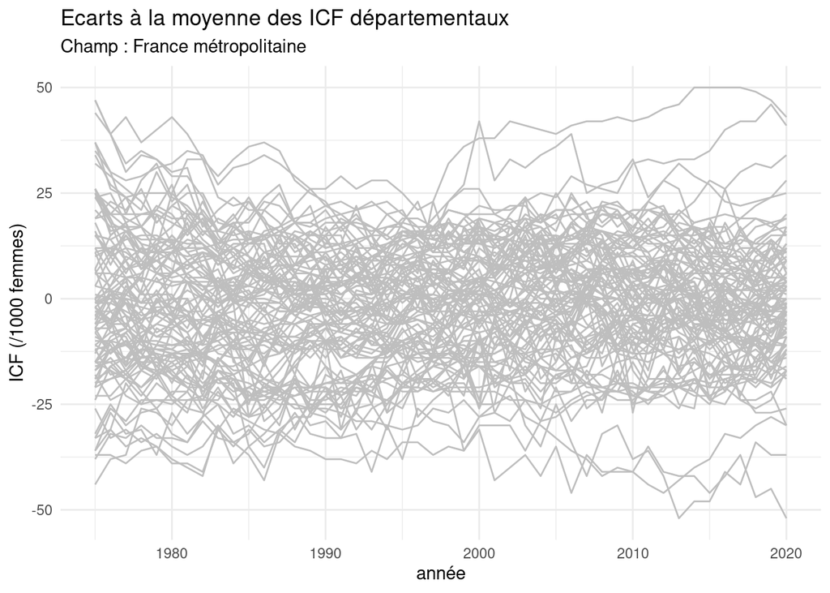

On s’appuie donc sur des mesures de la dispertion : écart-type et interquartile notamment. Néanmoins, les résultats de ces deux mesures ne sont pas forcément compatibles et constants : les écarts interquartiles sont clairement décroissants, mais l’écart-type est croissant depuis quelques années, avec un renversement vers les années 2000. Il est possible que certains “outliers” génèrent ces écarts et il faut travailler sur une vision plus individuelle.

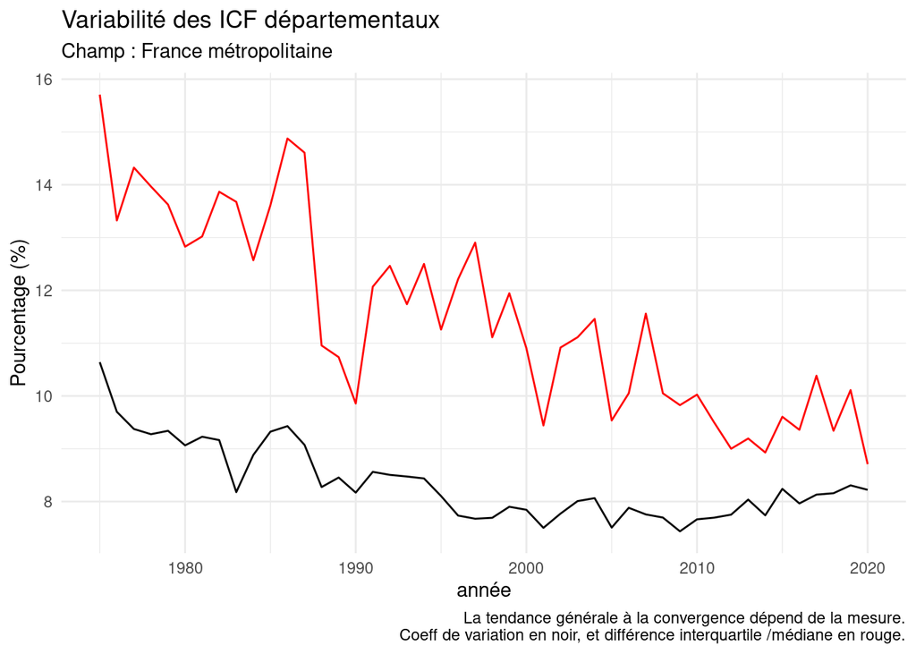

L’analyse individuelle consiste en la modélisation linéaire suivante :

$$(ICF_{dep,t}- ICF_{Fce,t})= \alpha + \beta t +\epsilon_t$$

Si le coefficient $_beta$ est positif, alors l’écart entre le département et la moyenne française augmente au cours du temps. Pour avoir une estimation de la “vitesse de convergence”, on analyse alors le paramètre $\zeta_{DEP}$, défini par : $\zeta_{DEP}=-\frac{\beta}{\overline{(ICF_{dep,t}- ICF_{Fce,t}})}$. Plus $\zeta$ est important, plus l’écart entre les deux séries diminue au cours du temps : on a convergence. Le tableau suivant permet de parcourir les valeurs prises à l’échelle départementale.

| Dép. | Caté. conv | zeta | ecart_moyen |
| --- | --- | --- | --- |
| 01 | (-0.06,-0.03] | 0 | 2.9 |
| 02 | (-0.03,0.03] | 0 | 18.1 |
| 03 | (-0.03,0.03] | 0 | -19.9 |
| 04 | (0.06, Inf] | 0.1 | -12.1 |
| 05 | (0.06, Inf] | 0.1 | -6.1 |
| 06 | (0.06, Inf] | 0.1 | -19.1 |
| 07 | (0.03,0.06] | 0.1 | -5.8 |
| 08 | (0.03,0.06] | 0 | 18.6 |
| 09 | (-0.03,0.03] | 0 | -23.6 |
| 10 | (-Inf,-0.06] | -0.3 | 1.6 |

[output cut: 86 more lines]

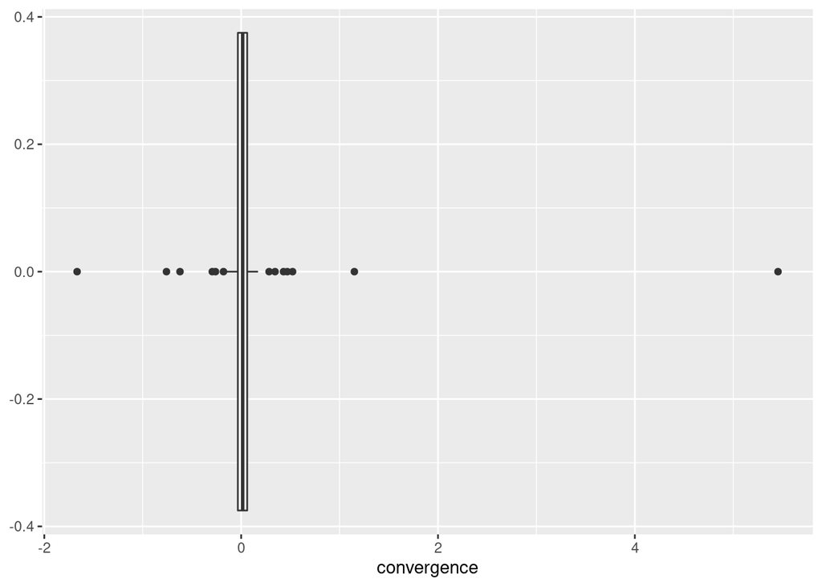